# 120 Lec 08

Tim Hagemeister

16 September, 2019

## Outliers

Note: robust statistics are not susceptible to outliers

lin reg stuff are not very robust – outliers can change our model!

Alwyas need to investigate, there are some common patterns. (see bord examples, text examples)

IN the text, influenctial poits are points that do affect the linear model. WE can ususally spot them: they are far away from the other (horizontally), and dont fit the linear pattern.

Summary from board examples:

Sometimes, outliers can make a weak relationship seem strong (eg #3). Sometimes, outliers can make a strong relationship seem weak. (eg #2). Sometiems, outliers dont really change anything. (eg #1).

Note: High leverage points are far away on x-axis (left/right). Note, it doenst have to be high leverage to change the model.

So generally, we run the number twice, it is easy to filter out the outliers, and chack for sure wheather or not the model was affected. R makes this easy!

## Examining the effects of outliers

```r
iris %>% head
```

```
##   Sepal.Length Sepal.Width Petal.Length Petal.Width Species
## 1          5.1         3.5          1.4         0.2  setosa
## 2          4.9         3.0          1.4         0.2  setosa
## 3          4.7         3.2          1.3         0.2  setosa
## 4          4.6         3.1          1.5         0.2  setosa
## 5          5.0         3.6          1.4         0.2  setosa
## 6          5.4         3.9          1.7         0.4  setosa
```

# first alwyas look at scatterplot

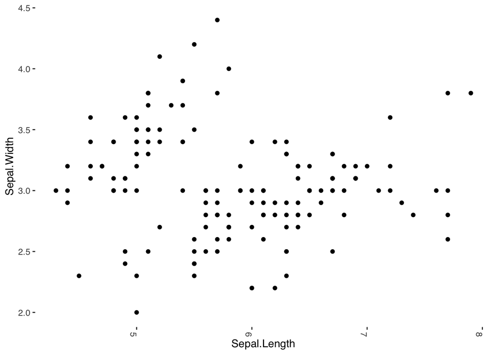

```r
ggplot(iris, aes(x=Sepal.Length, y=Sepal.Width))+
  geom_point()
```

```r
cor(iris$Sepal.Length, iris$Sepal.Width)
```

```
## [1] -0.1175698
```

The corelation is very weak, what is going on with the mode?

```r
# going to use lm

irisModel <- lm(Sepal.Width ~ Sepal.Length, data = iris)

summary(irisModel)
```

```
##
## Call:
## lm(formula = Sepal.Width ~ Sepal.Length, data = iris)
##
## Residuals:
##     Min      1Q  Median      3Q     Max
## -1.1095 -0.2454 -0.0167  0.2763  1.3338
##
## Coefficients:
##              Estimate Std. Error t value Pr(>|t|)
## (Intercept)   3.41895    0.25356   13.48   <2e-16 ***
## Sepal.Length -0.06188    0.04297   -1.44    0.152
## ---
## Signif. codes:  0 '***' 0.001 '**' 0.01 '*' 0.05 '.' 0.1 ' ' 1
##
## Residual standard error: 0.4343 on 148 degrees of freedom
## Multiple R-squared:  0.01382,    Adjusted R-squared:  0.007159
## F-statistic: 2.074 on 1 and 148 DF,  p-value: 0.1519
```

equation:

$$\hat{y} = 3.4189 - 0.0619x$$
Round to 3 decimals if you want,

Lets interprete the coeffs: